# Parte 3

Análisis descriptivo y exploratorio con R

CRG

2020-02-25

# 1 Importando la base de datos

La base de datos contiene las respuestas de un total de 33 de estudiantes, a diferentes preguntas hechas en el salón de clase.

```r
losdatos <- read.csv("Encuesta.csv" , dec = ",")
```

# 2 Análisis descriptivo

Se hará la descripción numérica de las variables haciendo uso de la funciones que proporciona [R](https://www.r-project.org/).

- `mean()`: obtener la media.
- `median()`: obtener la mediana.
- `mode()`: obtener la moda.
- `sd`: obtener la desviación estándar.
- `var()`: obtener la varianza.
- `min()`: obtener el valor mínimo.
- `max()`: obtener el valor máximo.
- `range()`: obtener el rango.
- `quantile()`: obtener cuartiles, deciles y percentiles.
- `IQR()`: obtener el rango intercuartílico.
- `table()`: obtener frecuencias absolutas.
- `prop.table()`: obtener frecuencias relativas.
- `summary()`: resumen numérico inicial de los datos.

# 3 Estructura de los datos

La estructura de la base de datos, evidencia que el número de filas presentes es de 33, y las variables (columnas) son 17.

La naturaleza de algunas variables:

- `Color` es factor
- `Redes` es numérica
- `Horas_dormir` es entero

```r
str(losdatos)
```

```
## 'data.frame':    33 obs. of  17 variables:
##  $ Color         : Factor w/ 8 levels "Amarillo","Azul",..: 2 2 2 6 1 7 4 8 7 2 ...
##  $ Vichada       : Factor w/ 4 levels "Florencia","Inírida",..: 4 3 3 3 4 4 1 1 4 4 ...
##  $ Redes         : int  4 1 3 2 6 1 3 3 4 3 ...
##  $ Promedio      : num  4.2 3.8 3.8 4.7 3.6 3.4 2.9 3.5 3.5 4 ...
##  $ Horas_acad    : num  48 10 28 20 40 20 4 10 10 11 ...
##  $ Hojarasca     : Factor w/ 5 levels "","FGL","GGM",..: 5 5 3 1 3 5 4 3 5 5 ...
##  $ Horas_dormir  : int  49 60 24 48 42 42 40 35 38 36 ...
##  $ Matematica    : num  3.5 5 5 4.5 4.7 4 3.8 5 4.8 5 ...
##  $ PAPA          : num  3.9 3.7 3.9 4.7 3.7 3.4 2.74 3.4 3.3 3.8 ...
##  $ Nicaragua     : Factor w/ 4 levels "","Managua","S. Domingo",..: 3 3 2 1 3 2 2 1 2 3 ...
##  $ Horas_internet: num  28 1 26 12 40 5 0.5 7 11 36 ...
##  $ Casa_univer   : int  7 45 80 30 40 20 90 22 15 45 ...
##  $ Transporte    : Factor w/ 4 levels "Bicicleta","Moto",..: 3 4 4 4 4 1 4 1 3 1 ...
##  $ PAPA2         : num  3.6 3.5 4 3.7 3.5 3.4 3.6 4 3.8 3.7 ...
##  $ Office        : num  3 3.5 3 3.5 3 4 2 3 2.5 2.5 ...
##  $ Trabajo       : Factor w/ 2 levels "No","Si": 2 1 2 2 1 2 2 1 1 2 ...
##  $ Carrera       : Factor w/ 2 levels "No","Si": 1 1 2 2 1 2 2 2 1 2 ...
```

```r
losdatos
```

| Color | Vichada | Redes | Promedio | Horas_acad | Hojarasca | Horas_dormir | Matematica | PAPA | Nicaragua | Horas_internet | Casa_univer | Transporte | PAPA2 | Office | Trabajo | Carrera |
| --- | --- | --- | --- | --- | --- | --- | --- | --- | --- | --- | --- | --- | --- | --- | --- | --- |
| Azul | P. Carreño | 4 | 4.2 | 48.0 | T. Carrasquilla | 49 | 3.5 | 3.90 | S. Domingo | 28.0 | 7 | Otro | 3.6 | 3.0 | Si | No |
| Azul | Mitú | 1 | 3.8 | 10.0 | T. Carrasquilla | 60 | 5.0 | 3.70 | S. Domingo | 1.0 | 45 | Urbano | 3.5 | 3.5 | No | No |
| Azul | Mitú | 3 | 3.8 | 28.0 | GGM | 24 | 5.0 | 3.90 | Managua | 26.0 | 80 | Urbano | 4.0 | 3.0 | Si | Si |
| Rojo | Mitú | 2 | 4.7 | 20.0 |  | 48 | 4.5 | 4.70 |  | 12.0 | 30 | Urbano | 3.7 | 3.5 | Si | Si |
| Amarillo | P. Carreño | 6 | 3.6 | 40.0 | GGM | 42 | 4.7 | 3.70 | S. Domingo | 40.0 | 40 | Urbano | 3.5 | 3.0 | No | No |
| Verde | P. Carreño | 1 | 3.4 | 20.0 | T. Carrasquilla | 42 | 4.0 | 3.40 | Managua | 5.0 | 20 | Bicicleta | 3.4 | 4.0 | Si | Si |
| Morado | Florencia | 3 | 2.9 | 4.0 | R. Pombo | 40 | 3.8 | 2.74 | Managua | 0.5 | 90 | Urbano | 3.6 | 2.0 | Si | Si |
| Vinotinto | Florencia | 3 | 3.5 | 10.0 | GGM | 35 | 5.0 | 3.40 |  | 7.0 | 22 | Bicicleta | 4.0 | 3.0 | No | Si |
| Verde | P. Carreño | 4 | 3.5 | 10.0 | T. Carrasquilla | 38 | 4.8 | 3.30 | Managua | 11.0 | 15 | Otro | 3.8 | 2.5 | No | No |
| Azul | P. Carreño | 3 | 4.0 | 11.0 | T. Carrasquilla | 36 | 5.0 | 3.80 | S. Domingo | 36.0 | 45 | Bicicleta | 3.7 | 2.5 | Si | Si |

[output cut: 23 more lines]

# 4 Variables cualitativas

## 4.1 Frecuencia absoluta

Para la pregunta:

**¿Cuántos estudiantes poseen trabajo remunerado al momento de responder la encuesta?**,

se obtienen las frecuencias absolutas.

```r
table(losdatos$Trabajo)
```

```
##
## No Si
## 13 20
```

## 4.2 Frecuencia relativa

Para la misma pregunta, se obtienen las frecuencias relativas y sus porcentajes:

```r
prop.table(table(losdatos$Trabajo))
```

```
##
##        No        Si
## 0.3939394 0.6060606
```

```r
prop.table(table(losdatos$Trabajo))*100
```

```
##
##       No       Si
## 39.39394 60.60606
```

# 5 Análisis gráfico con R

- *Gráficos para variables cuantitativas*:
  - hist(): función que permite construir histogramas.
  - density(): función que permite obtener densidades.
  - boxplot(): función que permite construir diagramas de cajas y bigotes.
  - plot(): función genérica que permite construir diagramas de dispersión (X vs Y).
- *Gráficos para variables cualitativas*:
  - barplot: función que permite construir diagrama de barras.
  - pie(): función que permite construir diagrama de sectores.

# 6 Variables cualitativas

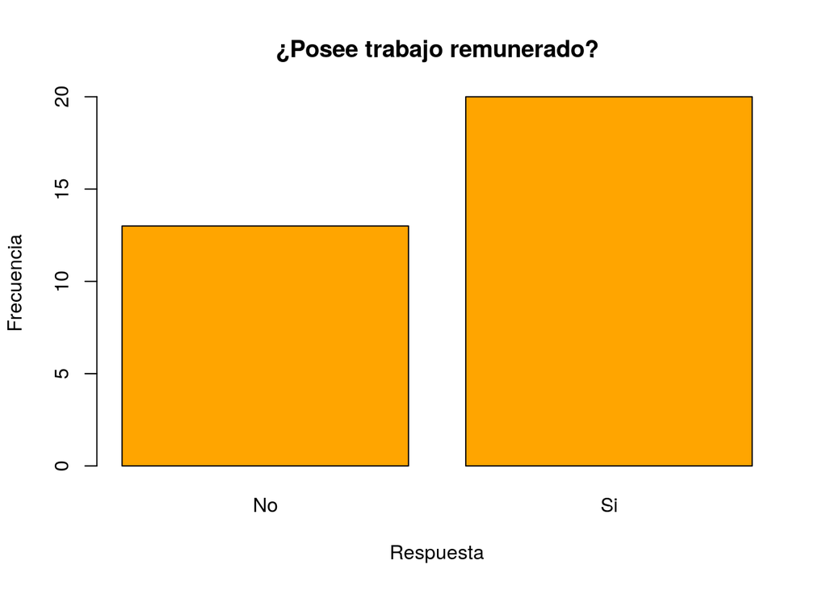

```r
barplot(table(losdatos$Trabajo),
        main = "¿Posee trabajo remunerado?",
        xlab = "Respuesta",
        ylab = "Frecuencia",
        col = "orange")
```

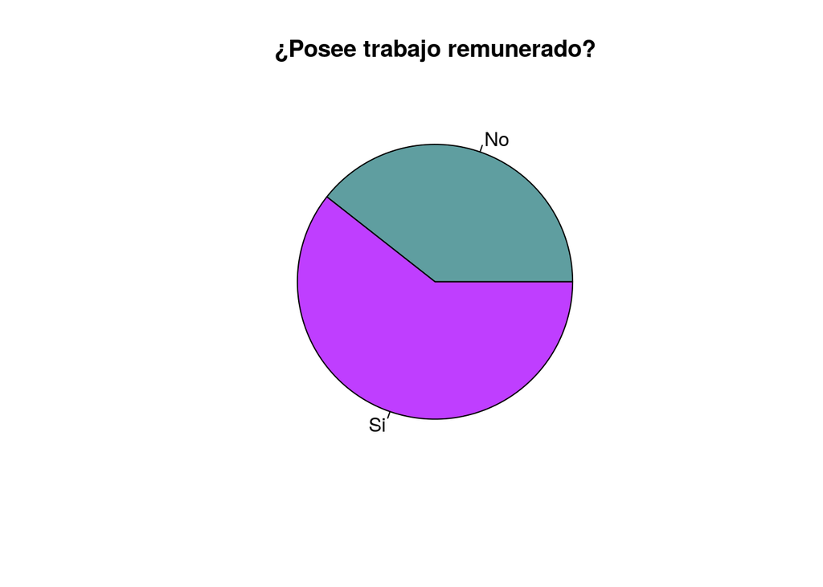

```r
pie(table(losdatos$Trabajo),
    main = "¿Posee trabajo remunerado?",
    col = c("cadetblue", "darkorchid1"))
```

**¿Cúal es el medio de transporte más utilizado por los estudiantes para dirigirse a la universidad?**

```r
table(losdatos$Transporte)
```

```
##
## Bicicleta      Moto      Otro    Urbano
##         6         2         7        18
```

```r
prop.table(table(losdatos$Transporte))
```

```
##
##  Bicicleta       Moto       Otro     Urbano
## 0.18181818 0.06060606 0.21212121 0.54545455
```

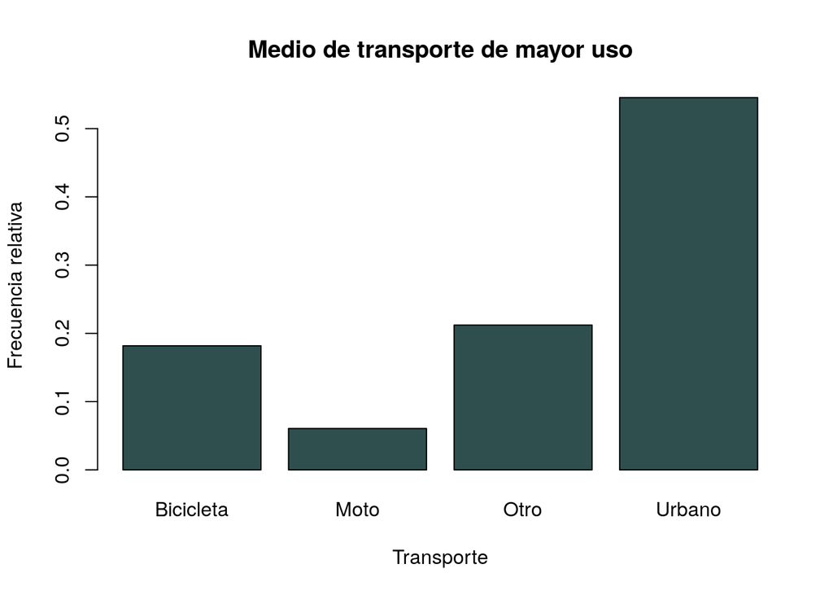

```r
barplot(prop.table(table(losdatos$Transporte)),
        main = "Medio de transporte de mayor uso",
        xlab = "Transporte",
        ylab = "Frecuencia relativa",
        col = "darkslategray")
```

**¿Cuál es el medio de transporte de mayor uso en estudiantes que poseen trabajo remunerado?**

```r
table(losdatos$Trabajo, losdatos$Transporte)
```

```
##
##      Bicicleta Moto Otro Urbano
##   No         2    0    2      9
##   Si         4    2    5      9
```

```r
prop.table(table(losdatos$Trabajo, losdatos$Transporte))
```

```
##
##       Bicicleta       Moto       Otro     Urbano
##   No 0.06060606 0.00000000 0.06060606 0.27272727
##   Si 0.12121212 0.06060606 0.15151515 0.27272727
```

```r
frecuencia <- table(losdatos$Trabajo, losdatos$Transporte)
```

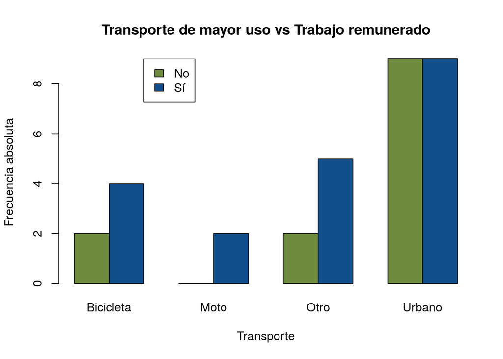

```r
barplot(frecuencia, beside = TRUE,
        main = "Transporte de mayor uso vs Trabajo remunerado",
        xlab = "Transporte",
        ylab = "Frecuencia absoluta",
        col = c("darkolivegreen4", "dodgerblue4"))
legend(x = 3, y = 9, c("No", "Sí"),
       fill = c("darkolivegreen4", "dodgerblue4"))
```

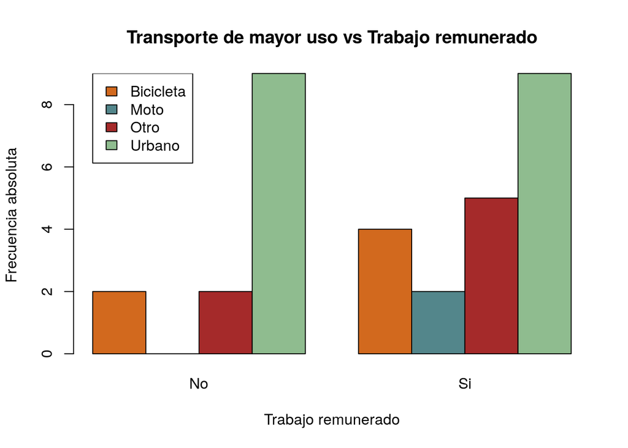

```r
barplot(t(frecuencia), beside = TRUE,
        main = "Transporte de mayor uso vs Trabajo remunerado",
        xlab = "Trabajo remunerado",
        ylab = "Frecuencia absoluta",
        col = c("chocolate", "cadetblue4", "brown", "darkseagreen"))

legend(x = 1, y = 9,
       c("Bicicleta", "Moto", "Otro", "Urbano"),
       fill = c("chocolate", "cadetblue4", "brown","darkseagreen"))
```

# 7 Variables cuantitativas

La variable PAPA es el Promedio Aritmético Ponderado Acumulado de cada estudiante, a lo largo de su carrera en la universidad. Los valores para esta variable van de cero $0$ a cinco $5$.

Se obtendrá la media, la varianza y la desviación estándar para esta variable.

```r
mean(losdatos$PAPA)
```

```
## [1] 3.543636
```

```r
var(losdatos$PAPA)
```

```
## [1] 0.1354614
```

```r
sd(losdatos$PAPA)
```

```
## [1] 0.3680508
```

Cuartiles variable PAPA:

$$Q_k = \frac{k(n+1)}{4}$$
$$Q_3= \frac{3(33+1)}{4} = 25.5$$

```r
n <- 33
q3 <- (3*(33+1))/4
q3
```

```
## [1] 25.5
```

```r
quantile(losdatos$PAPA)
```

```
##   0%  25%  50%  75% 100%
## 2.74 3.30 3.50 3.80 4.70
```

Ordenar los valores de la variable PAPA:

```r
ord.papa <- sort(losdatos$PAPA)
ord.papa
```

```
##  [1] 2.74 3.00 3.10 3.10 3.10 3.20 3.30 3.30 3.30 3.40 3.40 3.40 3.40 3.40
## [15] 3.40 3.50 3.50 3.50 3.70 3.70 3.70 3.70 3.70 3.80 3.80 3.80 3.80 3.80
## [29] 3.90 3.90 3.90 4.00 4.70
```

```r
ord.papa[3]
```

```
## [1] 3.1
```

```r
ord.papa[33]
```

```
## [1] 4.7
```

```r
ord.papa[25]
```

```
## [1] 3.8
```

```r
ord.papa[26]
```

```
## [1] 3.8
```

Deciles variable PAPA:

```r
quantile(losdatos$PAPA, probs = seq(0, 1, 0.10))
```

```
##   0%  10%  20%  30%  40%  50%  60%  70%  80%  90% 100%
## 2.74 3.10 3.30 3.40 3.40 3.50 3.70 3.74 3.80 3.90 4.70
```

Percentiles variable PAPA:

```r
quantile(losdatos$PAPA, probs = seq(0, 1, 0.01))
```

```
##     0%     1%     2%     3%     4%     5%     6%     7%     8%     9%
## 2.7400 2.8232 2.9064 2.9896 3.0280 3.0600 3.0920 3.1000 3.1000 3.1000
##    10%    11%    12%    13%    14%    15%    16%    17%    18%    19%
## 3.1000 3.1000 3.1000 3.1160 3.1480 3.1800 3.2120 3.2440 3.2760 3.3000
##    20%    21%    22%    23%    24%    25%    26%    27%    28%    29%
## 3.3000 3.3000 3.3000 3.3000 3.3000 3.3000 3.3320 3.3640 3.3960 3.4000
##    30%    31%    32%    33%    34%    35%    36%    37%    38%    39%
## 3.4000 3.4000 3.4000 3.4000 3.4000 3.4000 3.4000 3.4000 3.4000 3.4000
##    40%    41%    42%    43%    44%    45%    46%    47%    48%    49%
## 3.4000 3.4000 3.4000 3.4000 3.4080 3.4400 3.4720 3.5000 3.5000 3.5000
##    50%    51%    52%    53%    54%    55%    56%    57%    58%    59%
## 3.5000 3.5000 3.5000 3.5000 3.5560 3.6200 3.6840 3.7000 3.7000 3.7000
##    60%    61%    62%    63%    64%    65%    66%    67%    68%    69%
## 3.7000 3.7000 3.7000 3.7000 3.7000 3.7000 3.7000 3.7000 3.7000 3.7080
##    70%    71%    72%    73%    74%    75%    76%    77%    78%    79%
## 3.7400 3.7720 3.8000 3.8000 3.8000 3.8000 3.8000 3.8000 3.8000 3.8000
##    80%    81%    82%    83%    84%    85%    86%    87%    88%    89%
## 3.8000 3.8000 3.8000 3.8000 3.8000 3.8200 3.8520 3.8840 3.9000 3.9000
##    90%    91%    92%    93%    94%    95%    96%    97%    98%    99%
## 3.9000 3.9000 3.9000 3.9000 3.9080 3.9400 3.9720 4.0280 4.2520 4.4760
##   100%
## 4.7000
```

## 7.1 Histogramas y densidades

Distribución de la variable PAPA:

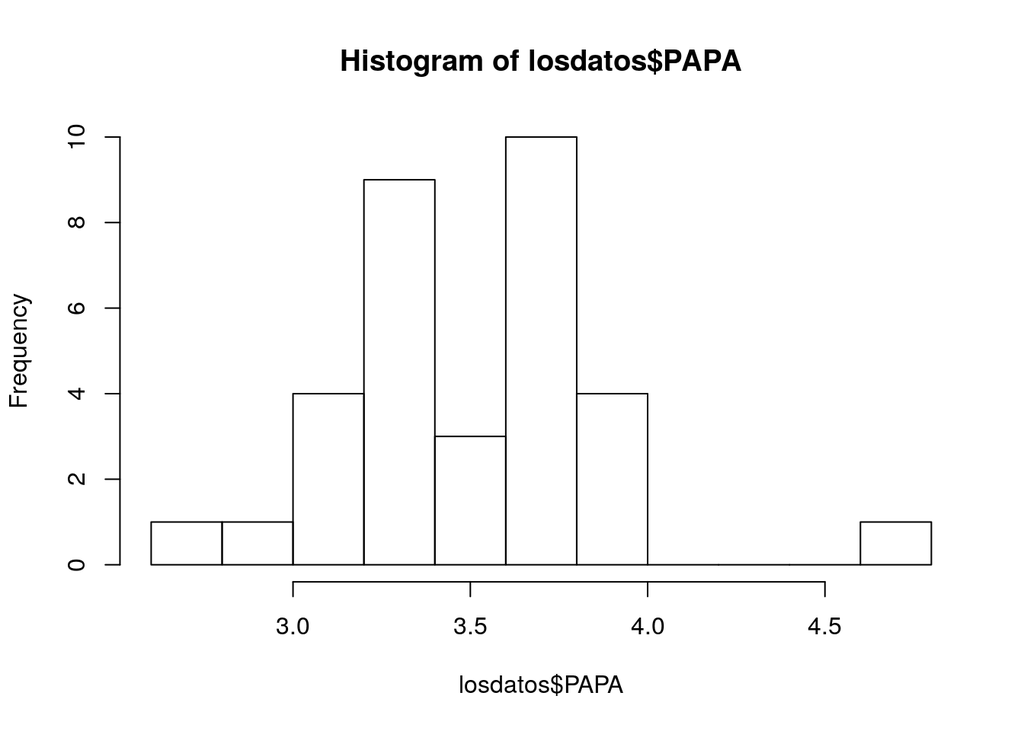

```r
hist(losdatos$PAPA)
```

Editando el histograma:

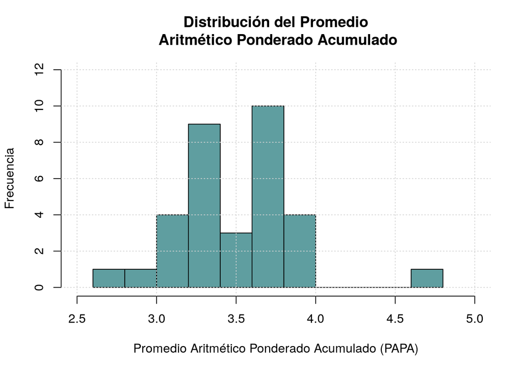

```r
hist(losdatos$PAPA,
     col = "cadetblue",
     main = "Distribución del Promedio\n Aritmético Ponderado Acumulado",
     xlab = "Promedio Aritmético Ponderado Acumulado (PAPA)",
     ylab = "Frecuencia",
     xlim = c(2.5, 5),
     ylim = c(0, 12))
grid()
```

Editando el histograma con línea de densidad:

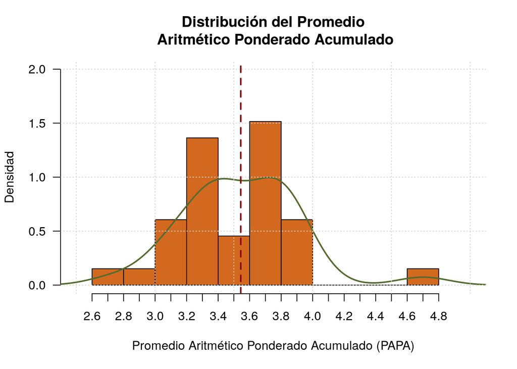

```r
hist(losdatos$PAPA,
     col = "chocolate",
     las = 1,
     main = "Distribución del Promedio\n Aritmético Ponderado Acumulado",
     ylab = "Densidad",
     xlab = "Promedio Aritmético Ponderado Acumulado (PAPA)",
     xlim = c(2.5, 5),
     ylim = c(0, 2),
     freq = FALSE,
     xaxt = "n")
axis(1, at = seq(2.6, 4.8, 0.1))
lines(density(losdatos$PAPA),
      col = "darkolivegreen",
      lwd = 2)
abline(v = mean(losdatos$PAPA), lwd = 2, lty = 2, col = "darkred")
grid()
```

## 7.2 Coeficiente de asimetría:

```r
library(moments)
skewness(losdatos$PAPA)
```

```
## [1] 0.53265
```

## 7.3 Coeficiente de curtosis:

```r
library(moments)
kurtosis(losdatos$PAPA)
```

```
## [1] 4.482118
```

## 7.4 Diagrama de cajas y bigotes (boxplot)

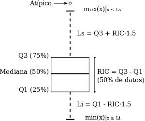

[Boxplot](https://2.bp.blogspot.com/-wVfcL_Gw3EE/VXC_T9iHL5I/AAAAAAAAAAc/_PscBwZm0ZQ/s400/Sin%2Bt%25C3%25ADtulo.png)

Función boxplot:

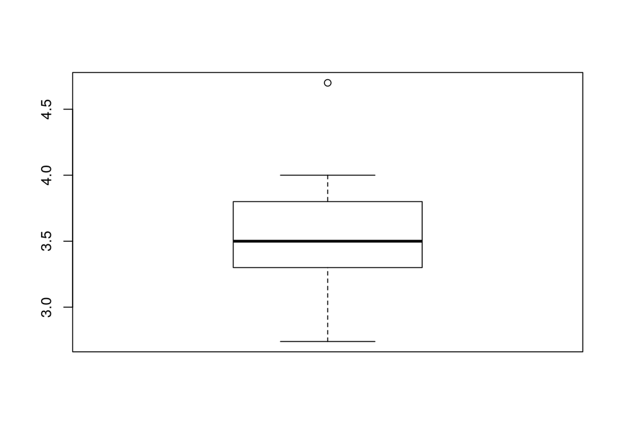

```r
boxplot(losdatos$PAPA)
```

Editando boxplot:

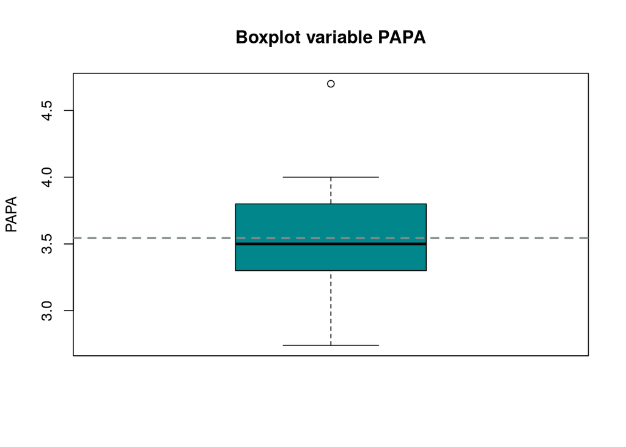

```r
boxplot(losdatos$PAPA,
        main = "Boxplot variable PAPA",
        xlab = "",
        ylab = "PAPA",
        col = "turquoise4")
abline(h = mean(losdatos$PAPA), col = "azure4",
       lwd = 2,
       lty = 2)
```

Boxplot comparativo (trabajo remunerado):

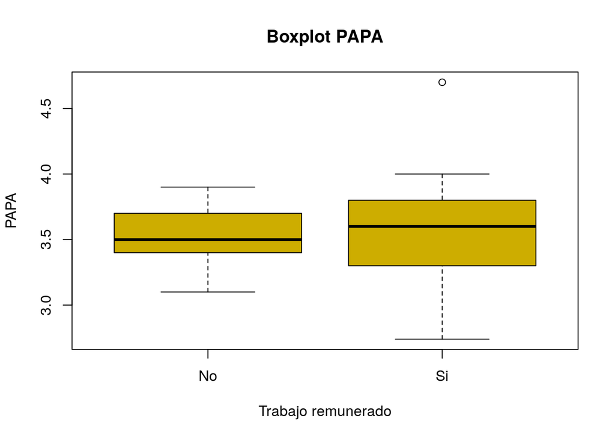

```r
boxplot(losdatos$PAPA ~ losdatos$Trabajo,
        main = "Boxplot PAPA",
        xlab = "Trabajo remunerado",
        ylab = "PAPA",
        col = "gold3")
```

Boxplot comparativo (carrera profesional como primera opción):

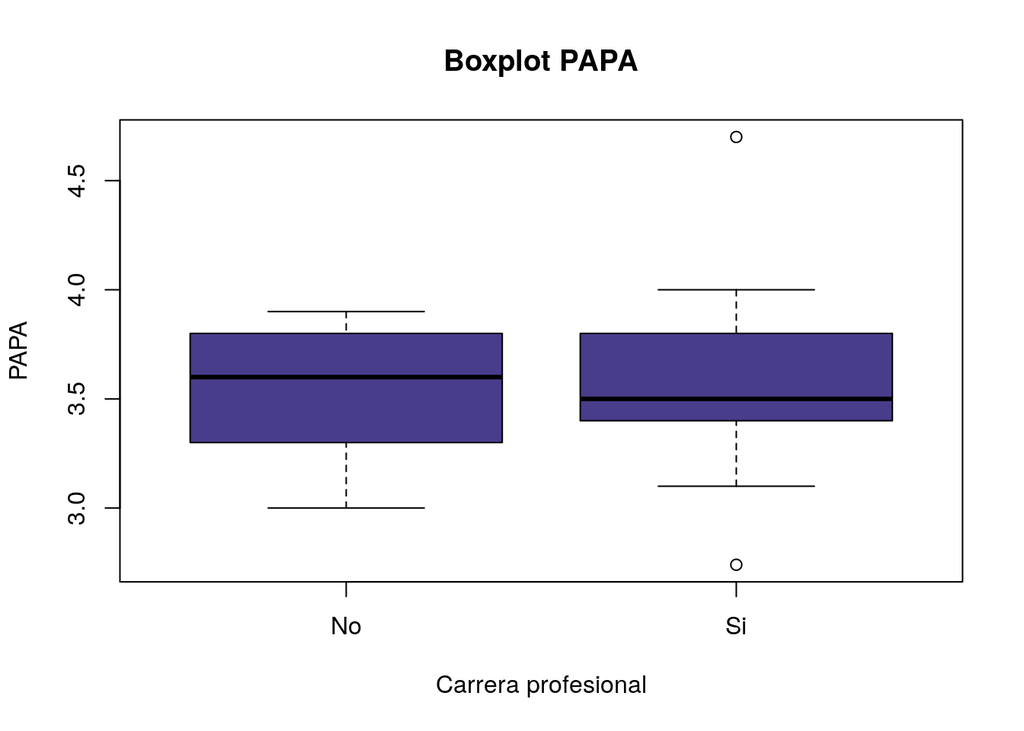

```r
boxplot(losdatos$PAPA ~ losdatos$Carrera,
        main = "Boxplot PAPA",
        xlab = "Carrera profesional",
        ylab = "PAPA",
        col = "darkslateblue")
```

## 7.5 Diagramas de dispersión

¿Es posible plantear que existe algún tipo de relación entre el PAPA y las horas que dedica el estudiante a las actividades académicas?

Función plot:

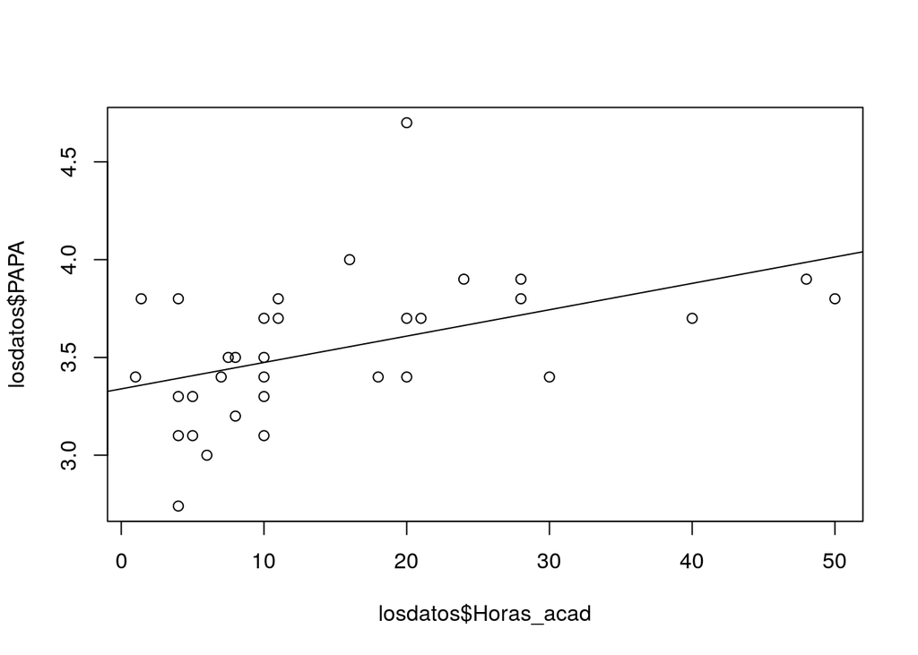

```r
plot(x = losdatos$Horas_acad,
     y = losdatos$PAPA)
abline(lm(losdatos$PAPA ~ losdatos$Horas_acad))
```

Edición del gráfico:

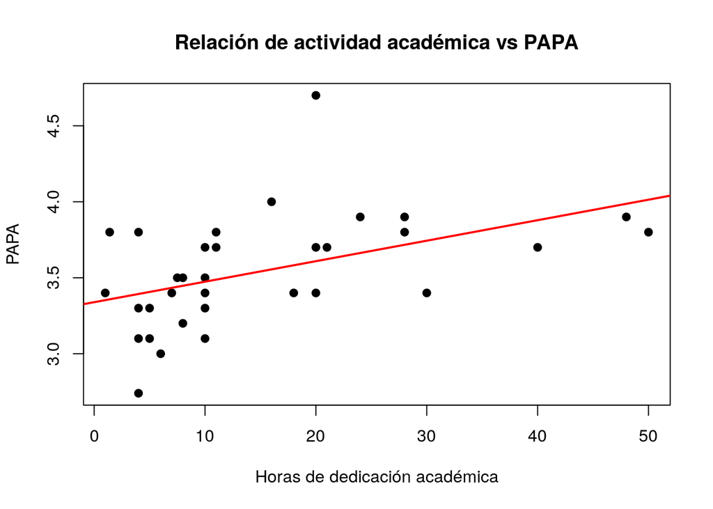

```r
plot(x = losdatos$Horas_acad,
     y = losdatos$PAPA,
     col = "black",
     pch = 19,
     xlab = "Horas de dedicación académica",
     ylab = "PAPA",
     main = "Relación de actividad académica vs PAPA")
abline(lm(losdatos$PAPA ~ losdatos$Horas_acad),
       lwd = 2,
       col = "red")
```

Gráfico construido con biblioteca `ggplot2`:

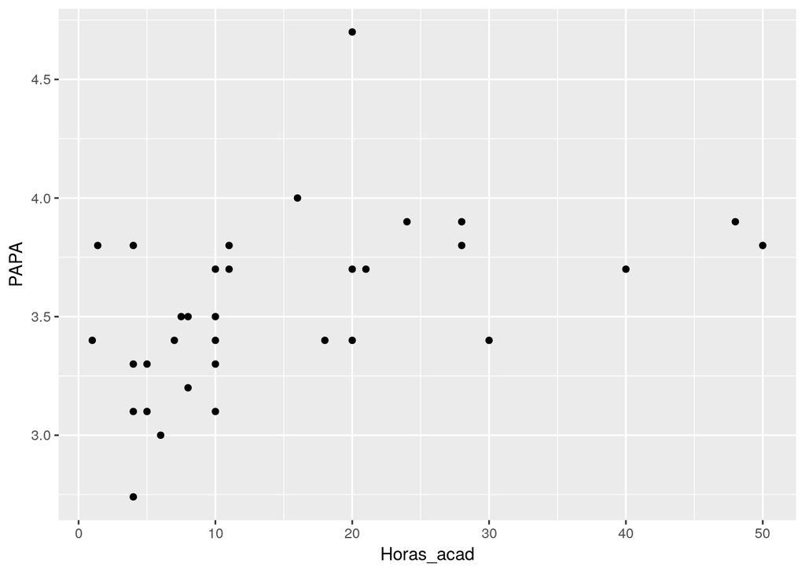

```r
library(ggplot2)
ggplot(data = losdatos,
       aes(x = Horas_acad,
           y = PAPA)) +
  geom_point()
```

Editando con `ggplot2`

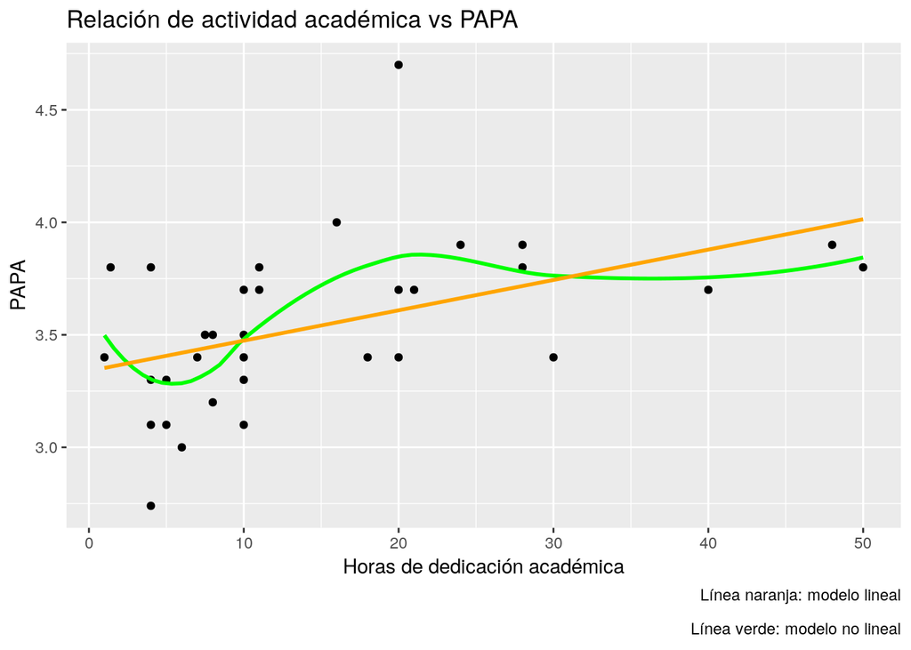

```r
ggplot(data = losdatos,
       aes(x = Horas_acad,
           y = PAPA)) +
  geom_point() +
  geom_smooth(se = FALSE, color = "green") +
  geom_smooth(method = "lm", se = FALSE, color = "orange") +
  labs(x = "Horas de dedicación académica",
       y = "PAPA",
       title = "Relación de actividad académica vs PAPA",
       caption = "Línea naranja: modelo lineal\n
       Línea verde: modelo no lineal")
```

## 7.6 Diagrama de barras para variables cuantitativas

```r
promedios <- tapply(X = losdatos$Casa_univer, INDEX = losdatos$Transporte, FUN = mean)
promedios
```

```
## Bicicleta      Moto      Otro    Urbano
##  25.33333  40.00000  13.42857  47.22222
```

Gráfico de barras para representar promedios:

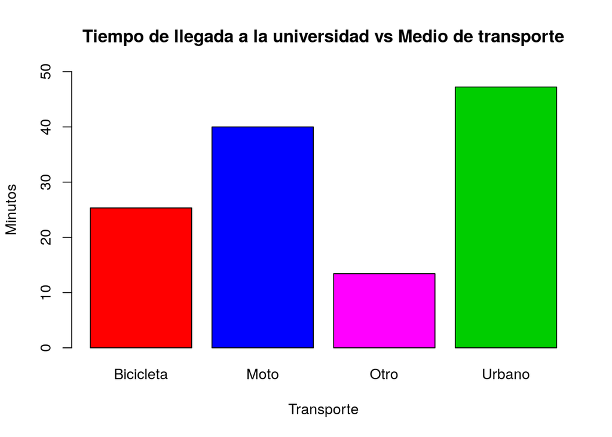

```r
barplot(promedios,
        main = "Tiempo de llegada a la universidad vs Medio de transporte",
        xlab = "Transporte",
        ylab = "Minutos",
        ylim = c(0, 50),
        col = c(2, 28, 6, 3))
```

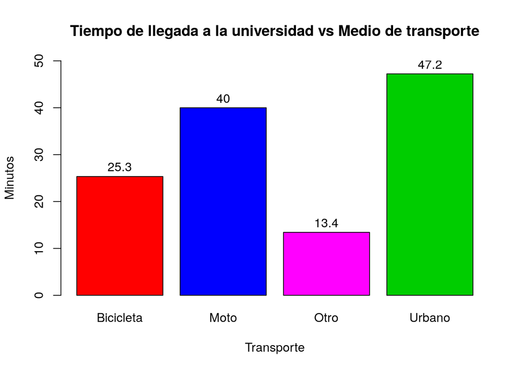

```r
barras <- barplot(promedios,
        main = "Tiempo de llegada a la universidad vs Medio de transporte",
        xlab = "Transporte",
        ylab = "Minutos",
        ylim = c(0, 50),
        col = c(2, 28, 6, 3))
text(x = barras,
     y = promedios + 2,
     labels = round(promedios,
                    digits = 1))
```

# 8 Resumen de las variables

```r
summary(losdatos)
```

```
##       Color          Vichada       Redes           Promedio
##  Azul    :12   Florencia : 4   Min.   : 1.000   Min.   :2.9
##  Morado  : 6   Inírida   : 2   1st Qu.: 3.000   1st Qu.:3.5
##  Rojo    : 6   Mitú      :11   Median : 3.000   Median :3.7
##  Verde   : 5   P. Carreño:16   Mean   : 3.394   Mean   :3.7
##  Amarillo: 1                   3rd Qu.: 4.000   3rd Qu.:3.8
##  Celeste : 1                   Max.   :10.000   Max.   :4.7
##  (Other) : 2
##    Horas_acad              Hojarasca   Horas_dormir     Matematica
##  Min.   : 1.00                  : 5   Min.   : 8.00   Min.   :2.100
##  1st Qu.: 6.00   FGL            : 2   1st Qu.:36.00   1st Qu.:3.800
##  Median :10.00   GGM            : 7   Median :42.00   Median :4.500
##  Mean   :15.15   R. Pombo       : 5   Mean   :42.21   Mean   :4.285
##  3rd Qu.:20.00   T. Carrasquilla:14   3rd Qu.:49.00   3rd Qu.:5.000
##  Max.   :50.00                        Max.   :60.00   Max.   :5.000
##
##       PAPA            Nicaragua  Horas_internet   Casa_univer
##  Min.   :2.740             : 6   Min.   : 0.50   Min.   : 7.00
##  1st Qu.:3.300   Managua   :18   1st Qu.:10.00   1st Qu.:20.00
##  Median :3.500   S. Domingo: 6   Median :15.00   Median :30.00
##  Mean   :3.544   S. José   : 3   Mean   :20.62   Mean   :35.64
##  3rd Qu.:3.800                   3rd Qu.:24.00   3rd Qu.:45.00
##  Max.   :4.700                   Max.   :90.00   Max.   :90.00
##
##      Transporte     PAPA2           Office      Trabajo Carrera
##  Bicicleta: 6   Min.   :3.300   Min.   :1.000   No:13   No:18
##  Moto     : 2   1st Qu.:3.500   1st Qu.:2.500   Si:20   Si:15
##  Otro     : 7   Median :3.700   Median :3.000
##  Urbano   :18   Mean   :3.697   Mean   :3.015
##                 3rd Qu.:3.900   3rd Qu.:3.500
##                 Max.   :4.000   Max.   :4.500
##
```

# 9 Referencias

- https://bioestadistica.github.io/
- https://www.r-project.org/
- https://www.r-graph-gallery.com/ggplot2-color.html